# Lecture 6: Point Level Models - Variograms & EDA

# Class Intro

## Intro Questions

- What is a variogram?
- How is a variogram useful?
- For Today:
  - How is EDA used for point referenced data?

# Variogram Creation

## Variogram Creation: How?

| x | y | copper |
| --- | --- | --- |
| 181072 | 333611 | 85 |
| 181025 | 333558 | 81 |
| 181165 | 333537 | 68 |
| 181298 | 333484 | 81 |
| 181307 | 333330 | 48 |
| 181390 | 333260 | 61 |
| 181165 | 333370 | 31 |
| 181027 | 333363 | 29 |
| 181060 | 333231 | 37 |
| 181232 | 333168 | 24 |
| 181191 | 333115 | 25 |
| 181032 | 333031 | 25 |
| 180874 | 333339 | 93 |
| 180969 | 333252 | 31 |
| 181011 | 333161 | 27 |

## Variogram Creation: Steps

1. Calculate distances between sampling locations
2. Choose grid for distance calculations
3. Calculate empirical semivariogram
   $$\hat{\gamma}(d_k) = \frac{1}{2N(d_k)} \sum_{\boldsymbol{s}_i,\boldsymbol{s}_i, \in N(d_k)}\left[ \boldsymbol{Y}(\boldsymbol{s}_i) - \boldsymbol{Y}(\boldsymbol{s}_j) \right]^2,$$
   where
   $$N(d_k) = \{(\boldsymbol{s}_i,\boldsymbol{s}_j): ||\boldsymbol{s}_i -\boldsymbol{s}_j|| \in I_k\}$$
   and $I_k$ is the $k^{th}$ interval.
4. Plot the semivariogram

## Variogram Creation: R function

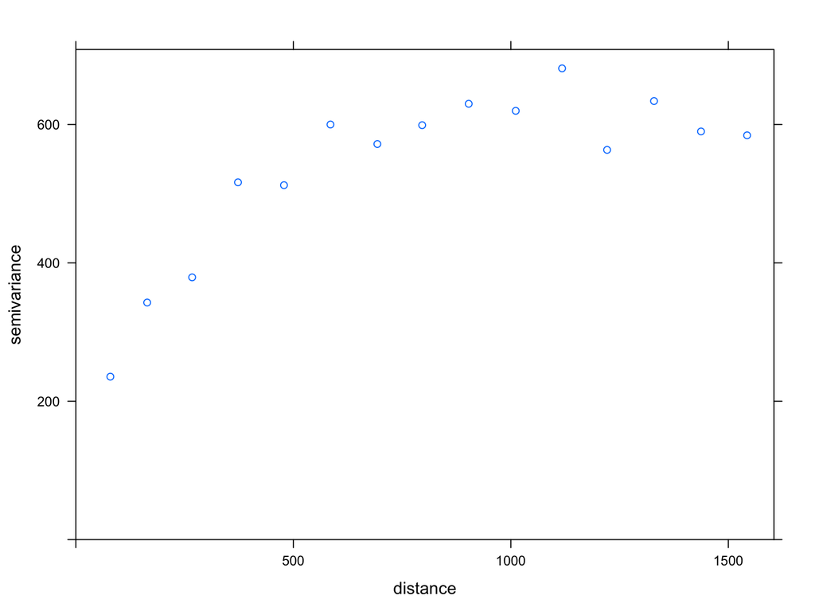

## Variogram Creation: How - Step 1

Calculate Distances between sampling locations

```r
dist(meuse.small)
```

[output not shown]

[output cut: 3975 more lines]

[output not shown]

```r
dist.mat <- dist(meuse.small %>% select(x,y))
```

## Variogram Creation: How - Step 2

Choose grid for distance calculations

```r
cutoff <- max(dist.mat) / 3 # default maximum distance
num.bins <-  15
bin.width <- cutoff / 15
```

## Variogram Creation: How - Step 3

Calculate empirical semivariogram

```
## # A tibble: 15 x 2
##      bin emp.sv
##    <dbl>  <dbl>
##  1     1   236.
##  2     2   347.
##  3     3   348.
##  4     4   488.
##  5     5   499.
##  6     6   577.
##  7     7   553.
##  8     8   623.
##  9     9   600.
## 10    10   665.
## 11    11   603.
## 12    12   673.
## 13    13   557.
## 14    14   643.
## 15    15   574.
```

## Variogram Creation: How - Step 4

Plot empirical semivariogram

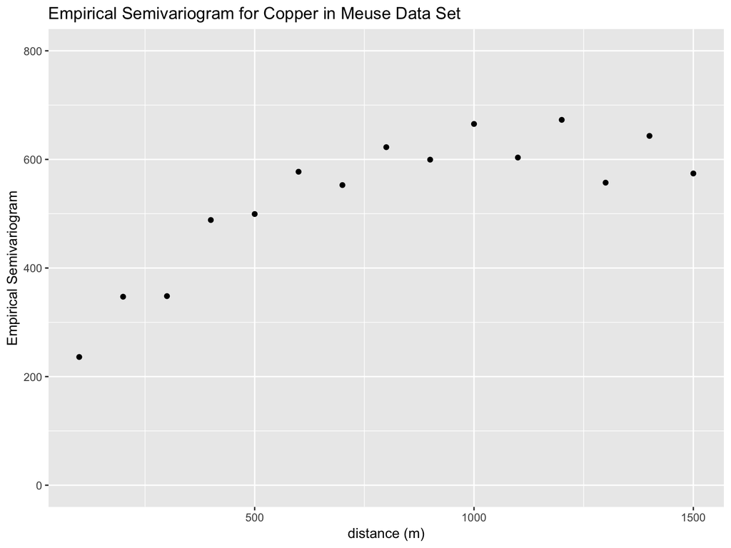

## Variogram Fitting

Now given this empirical semivariogram, how to we choose a semivariogram (and associated covariance structure) and estimate the parameters in that function??

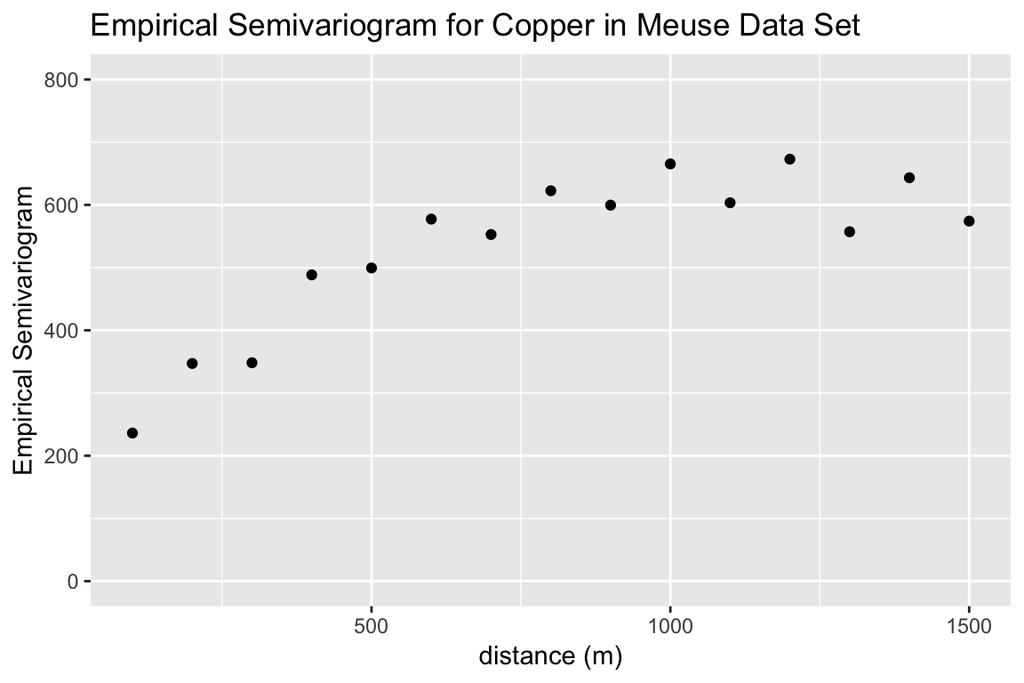

## Variogram Fitting, cont..

- Empirical semivariograms can be computed and plotted, but they are subject to researcher choice: such as bin width and the number of points to display.
- The “data points” here is really a function of the observed random variable, but do not have an associated likelihood.
- Variogram fitting is very much an art and not a science.
- Eventually maximum likelihood or Bayesian methods will be used to estimate parameters in the covariance model directly.

# Exploratory Data Analysis

## EDA Overview

- Exploratory Data Analysis (EDA) is commonly used to explore and visualize data sets.
- EDA is not a formal analysis, but can inform modeling decisions.
- What are we interested in learning about with spatial data?

## Data Decomposition: Time Series

- In time series analysis, the first step in the EDA process was to decompose the observed data into a trend, seasonal cycles, and a random component.

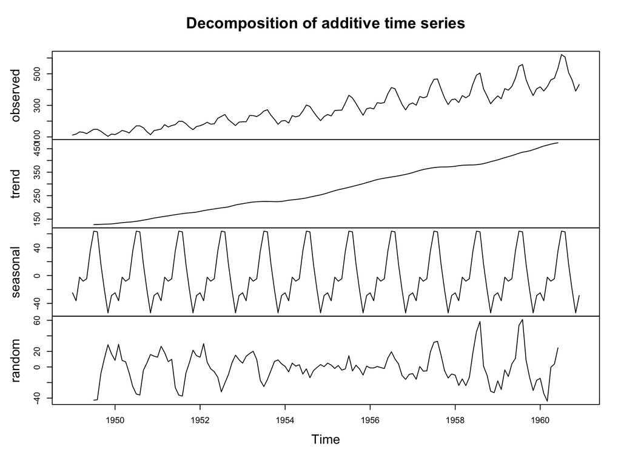

## Data Decomposition: Spatial Data

- Similarly spatial data will be decomposed into the mean surface and the error surface.
- For example, elevation and distance from major bodies of water would be part of the mean surface for temperature.
- The mean surface is focused on the global, or first-order, behavior.
- The error surface captures local fluctuations, or second-order, behavior.

## Response Surface vs. Spatial Surface

- Spatial structure in the response surface and spatial structure in the error surface are not one-and-the-same.
- $E[(Y(\boldsymbol{s})-\mu)(Y(\boldsymbol{s'})-\mu)]$ vs. $E[(Y(\boldsymbol{s})-\mu(\boldsymbol{s}))(Y(\boldsymbol{s'})-\mu(\boldsymbol{s}))]$
- There are stationarity implications for considering the residual surface.
- Data sets contain two general types of useful information: spatial coordinates and covariates.
- Regression models will be used to build the mean surface.

## Spatial EDA Overview

1. Map of locations
2. Histrogram or other distributional figure
3. 3D scatterplot
4. General Regression EDA
5. Variograms and variogram clouds
6. Anistopic diagnostics

# Scallops Data Example

## 1. Map of Locations

[interactive chart not shown]

## 1. Map of Locations - Takeaways

*Goal*: Understand the sampling approach

- Is this a grid?
- Are there directions that have larger distances?
- How large is the spatial extent?

## 2. Histogram

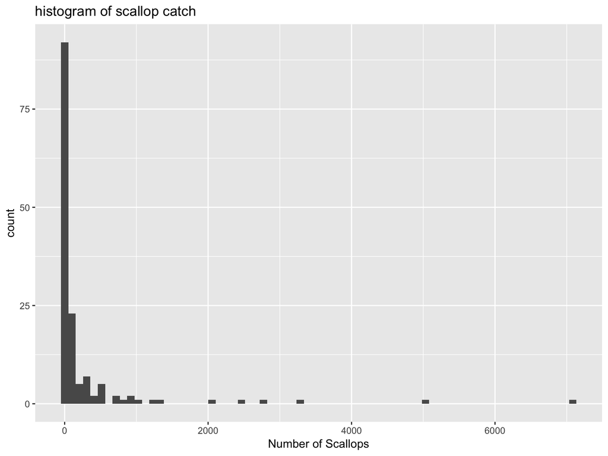

## 2. Histogram

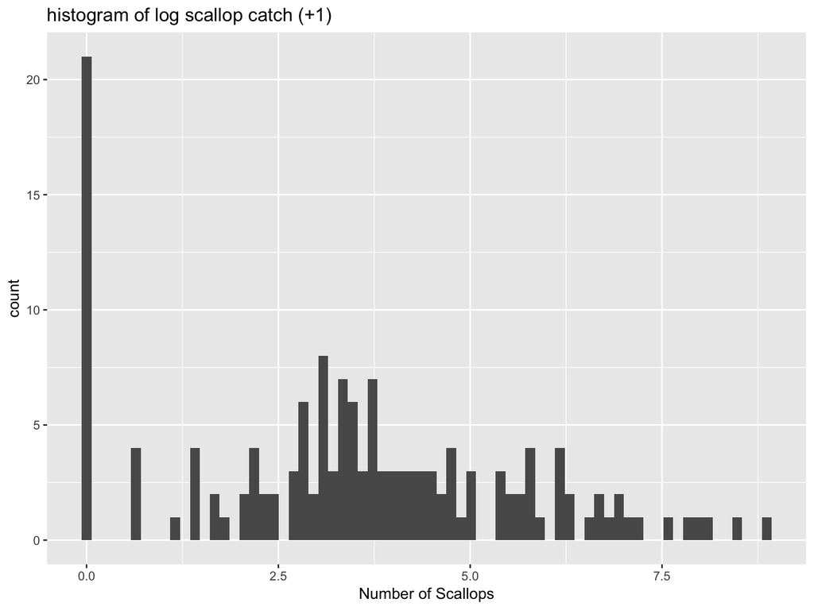

## 2. Histogram - Takeaways

*Goal:* Identify a sampling distribution for the data

- Continuous or discrete data
- A linear model approach will be used for the response
- Spatial structure can also be included in generalized linear models
- Outliers are worth investigating, but a data point that does not fit the assumed model should not automatically be eliminated

## 3. 3D scatterplot

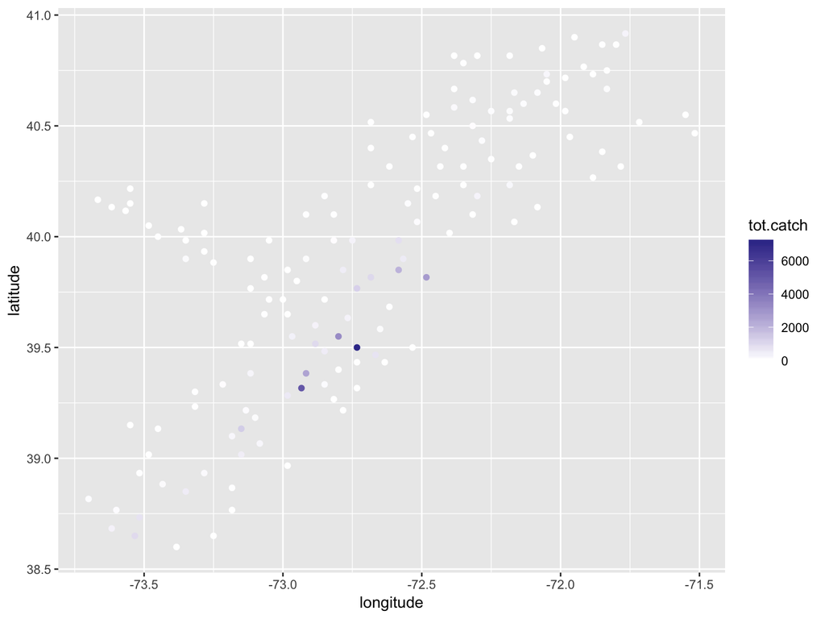

## 3. 3D scatterplot

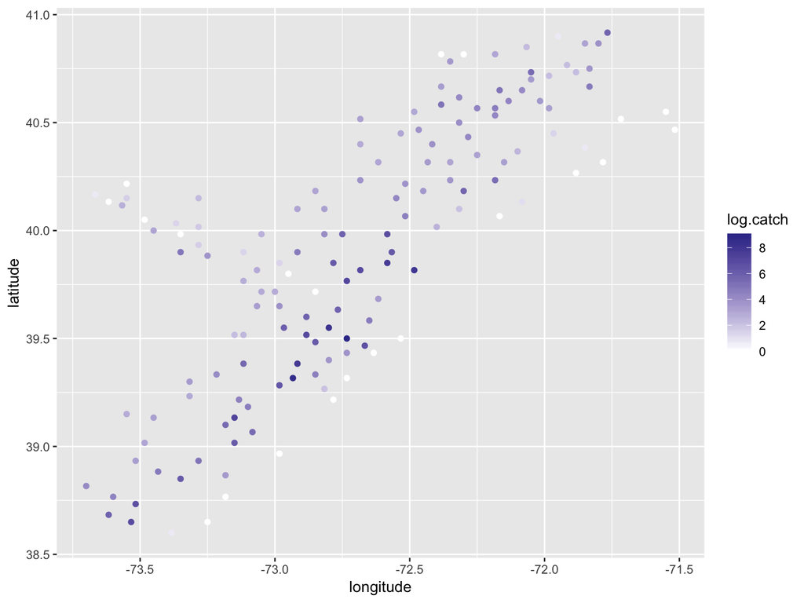

## 3. 3D scatterplot - Takeaways

*Goal:* Examine the spatial pattern of the response

- Again, this is the response not the residual
- Can also think about a contour plot (using some interpolation method)

## 4. General Regression EDA

- Assessing relationship between variable of interest and covariate information
- No covariates are present in the scallops data

## 5. Variograms and variogram clouds: Exercise

Explore the code below: what are the differences in the three variograms?

```r
coordinates(scallop) = ~longitude+latitude
class(scallop)
scallop.sp <- scallop
proj4string(scallop.sp) <- CRS("+proj=longlat +datum=WGS84")  ## for example
scallop.utm <- spTransform(scallop.sp, CRS("+proj=utm +zone=18 ellps=WGS84"))

plot(variogram(log.catch~1, scallop))
plot(variogram(log.catch~1, scallop.sp))
plot(variogram(log.catch~1, scallop.utm))
```

## 5. Variograms

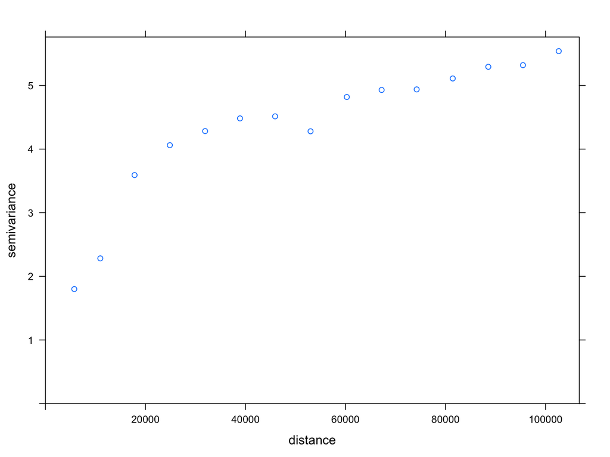

## 5. Variogram Cloud

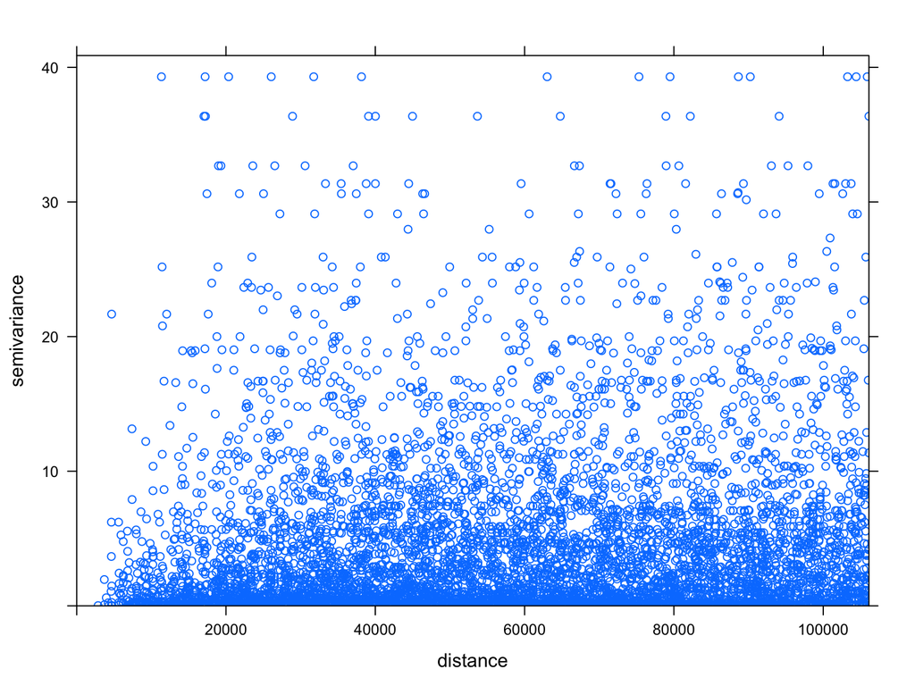

## 5. Variograms and variogram clouds: Takeaways

*Goal:* Visually diagnose spatial structure

## 6. Anisotropy

*Goal:* Determine if direction influencs spatial structure

# Anisotropy

## Directional Variogram

- All of the variograms we have looked at are isotropic

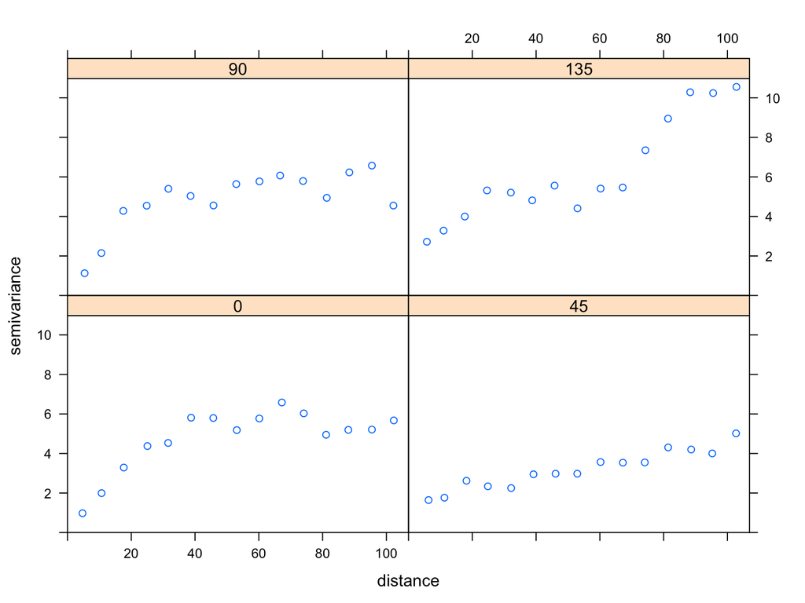

## Separable Correlations Functions

- If the differences in spatial structure are directly related to two coordinate sets, we can create a stationary, anistropic covariance function
- Let
  $$cor(Y(\boldsymbol{s + h}), Y(\boldsymbol{s})) = \rho_1(h_y) \rho_2(h_x),$$
  where $\rho_1()$ and $\rho_2()$ are proper correlation functions.
- A scaling factor, $\sigma^2,$ can be used to create covariance.

## Geometric Anistropy

- Another solution is the class of geometric anisotropic covariance functions with
  $$C(\boldsymbol{s} - \boldsymbol{s'}) = \sigma^2 \rho((\boldsymbol{s} - \boldsymbol{s'})^TB(\boldsymbol{s} - \boldsymbol{s'})),$$
  where $B$ is positive definite matrix and $\rho$ is a valid correlation function
- $B$ is often referred to as a transformation matrix which rotates and scales the coordinates, such that the resulting transformation can be simplified to a distance.

## Sill, Nugget, and Range Anisotropy

- Recall the sill is defined as $\lim_{d \rightarrow \infty} \gamma(d)$
- Let $\boldsymbol{h}$ be an arbitrary separation vector, that can be normalized as $\frac{\boldsymbol{h}}{||\boldsymbol{h}||}$
- If $\lim_{a \rightarrow \infty} \gamma(a \times \frac{\boldsymbol{h}}{||\boldsymbol{h}||})$ depends on $\boldsymbol{h}$, this is referred to as sill anisotropy.
- Similarly the nugget and range can depend on $\boldsymbol{h}$ and give nugget anisotropy and range anisotropy

# Model Fitting

## Simulating Spatial Process

- Soon we will look at fitting models for spatial point data
- Simulating data gives a deeper understanding of the model fitting process
- Simulate a mean-zero, isotropic spatial process with a spherical covariance function

## Additional Resources

- [Meuse Data Tutorial](https://cran.r-project.org/web/packages/gstat/vignettes/gstat.pdf)
- [Textbook Data Sets](https://www.counterpointstat.com/hierarchical-modeling-and-analysis-for-spatial-data.html/)